# Geospatial Analysis and Representation for Data Science Project

## The Local Moran’s I

The Moran scatterplot represents a useful and intuitive visual representation of local patterns of spatial association, but it cannot provide statistical significance of the results. For this reason, to assess the significance of the revealed pattern, we can rely on the so-called local Moran I index:

```r
lmI = localmoran(BZ_dolomiti_ski_areas$prices, dnb159.listw)
head(lmI)
```

```
##            Ii         E.Ii     Var.Ii        Z.Ii Pr(z != E(Ii))
## 1 -0.03776105 -0.017915827 0.06909978 -0.07549491      0.9398209
## 2 -0.27668756 -0.015376377 0.03775155 -1.34490190      0.1786569
## 3 -0.03586392 -0.012625307 0.06459607 -0.09143388      0.9271478
## 4 -0.12610217 -0.012625307 0.09066115 -0.37687445      0.7062669
## 5  0.29516084 -0.006565256 0.02561427  1.88526256      0.0593944
## 6 -0.04468586 -0.015376377 0.07845244 -0.10464174      0.9166601
```

```r
lmI = localmoran(BZ_dolomiti_ski_areas$prices, knn6BZ.listw)
head(lmI)
```

```
##            Ii         E.Ii     Var.Ii       Z.Ii Pr(z != E(Ii))
## 1 -0.03996608 -0.017915827 0.05438408 -0.0945535     0.92466949
## 2 -0.25917800 -0.015376377 0.04679619 -1.1270193     0.25973434
## 3  0.09139515 -0.012625307 0.03853099  0.5299241     0.59616456
## 4  0.10065035 -0.012625307 0.03853099  0.5770740     0.56388946
## 5  0.28448232 -0.006565256 0.02015938  2.0498656     0.04037755
## 6 -0.08554151 -0.015376377 0.04679619 -0.3243516     0.74567184
```

We can also plot the distribution of local Moran’s I-index values:

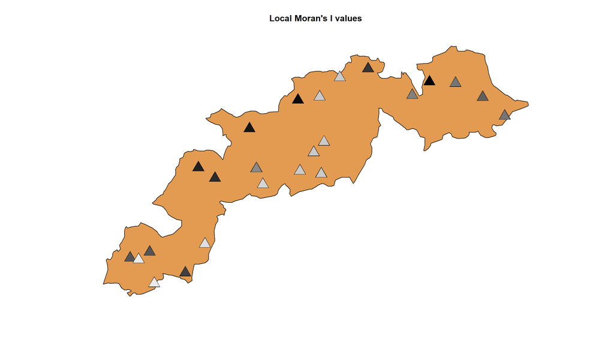

```r
brks = sort(as.numeric(lmI[,1]))
colours = grey((0:length(lmI[,1]))/length(lmI[,1]))

plot(area_dolomiti_BZ, col = "#E29B50")
points(BZ_dolomiti_ski_areas, col = "black", cex = 2.75, pch = 17)
points(BZ_dolomiti_ski_areas, col = colours[findInterval(lmI[,1], brks, all.inside = TRUE)], cex = 2.5, pch = 17)
title(main = "Local Moran's I values")
```

With this representation we can identify which ski areas have a positive **local** spatial correlation, in white (or light grey), and which have a negative one, in dark. However, it should be borne in mind that this index does not provide us with information on the significance of results.

As previously done with the global index, Moran’s local I-statistic can also be tested for deviations using the null hypothesis of no local spatial autocorrelation and thus can provide the statistical significance of the local spatial patterns detected by Moran’s scatterplot. Thus, we can map the corresponding p-values:

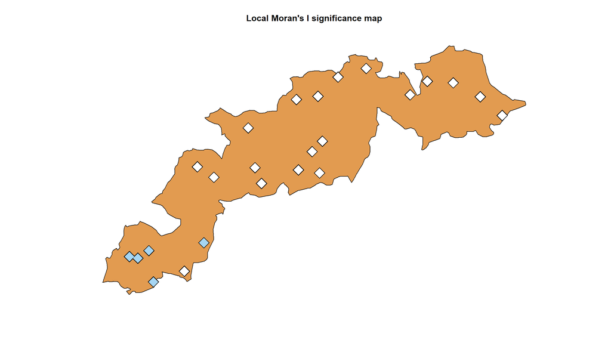

```r
pval = as.numeric(lmI[,5])
BZ_dolomiti_ski_areas$colpval[pval>0.05] = "white"
BZ_dolomiti_ski_areas$colpval[pval<=0.05 & pval>0.01] = "#A5D5F3"
BZ_dolomiti_ski_areas$colpval[pval<=0.01 & pval>0.001] = "#6FBCEB"
BZ_dolomiti_ski_areas$colpval[pval<=0.001 & pval>0.0001] = "#3AA3E4"
BZ_dolomiti_ski_areas$colpval[pval<=0.0001] = "#1878B4"

plot(area_dolomiti_BZ, col = "#E29B50")
points(BZ_dolomiti_ski_areas, col="black", pch=18, cex=3.5)
points(BZ_dolomiti_ski_areas, col=BZ_dolomiti_ski_areas$colpval, pch=18, cex=3)
legend(x=-10, y=73, legend=c("Not significant",
       "p-value = 0.05", "p-value = 0.01", "p-value = 0.001",
       "p-value = 0.0001"), fill=c("white", gray(0.9), gray(0.7),
       gray(0.4), "black"), bty="n", cex=0.8)
title(main="Local Moran's I significance map")
```

Only a few of the ski areas have a significant spatial correlation. These are at the bottom left of the map and are: Carezza, Nova Ponente, Panorama, Pietralba e Passo Olcini (which also correspond to point 17, the one with the most influence)

## Conclusion

If we consider the global spatial autocorrelation, we did not obtain significant results with most of the chosen neighbouroods. The p-value was significant only when we considered many neighbours for each ski area; however, the Moran I statistic value was just above 0, indicating an extremely slight positive correlation.

On the other hand, considering the local index we find (again using quite high number of neighbours or a quite high distance) that there are some ski areas that have significant positive or negative spatial autocorrelation.